# Fun and Easy TCO data

This short slide deck illustrates how well structured data combined with an intake catalog can be easy to browse and explore. Topics can be explored in more depth by clicking down, or a new topic can be opened by clicking right.

## Opening the catalog

The Tropical Cloud Observations Group of the Max Planck Institute for Meteorology decided to serve all of its data using zarr over html. The data is compiled (or is being compiled) as a single data set, using intake and the catalog:

"http://tcodata.mpimet.mpg.de/catalog.yaml"

Presently only a few instruments have been added, more or on their way.

Below we give some examples showing how to navigate through the catalog. Next we give some examples using the data files that we identified by browsing.

```python
import intake
cat = intake.open_catalog("http://tcodata.mpimet.mpg.de/catalog.yaml")
```

```python
for c in list(cat):
    print (f"Instruments in the '{c}' collection:")
    for x in list(cat[c]):
        print (f"\t{x}")
```

```
Instruments in the 'Level_1' collection:
	Meteorology_2m
	Backscatter_MBR2
	CORAL_LR_t
	CORAL_LR_b
Instruments in the 'BCO' collection:
	surfacemet_wxt_v1
	radar_MBR2_c1_v1
	radar_MBR2_c2_v1
	radar_MBR2_c3_v1
	radar_MBR2_c4_v1
	radar_MBRS_c1_v1
```

```python
print('Data variables in surfacemet_wxt_v1:',[v for v in cat.BCO.surfacemet_wxt_v1.to_dask().data_vars],'\n')
print('Data variables in radar_MBRS_c1_v1:',[v for v in cat.BCO.radar_MBRS_c1_v1.to_dask().data_vars],'\n' )
```

```
Data variables in surfacemet_wxt_v1: ['DIR', 'DL', 'DR', 'H', 'HDH', 'HDS', 'HI', 'HP', 'MNV', 'MXHI', 'MXRI', 'MXV', 'P', 'R', 'RDH', 'RDS', 'RH', 'RI', 'RP', 'SDQ', 'T', 'TH', 'TI', 'VEL', 'VH', 'VR', 'VS']

Data variables in radar_MBRS_c1_v1: ['HSDco', 'HSDcx', 'LDR', 'LDRg', 'MeltHei', 'RMS', 'RMSg', 'RadarConst', 'SNR', 'SNRg', 'SNRplank', 'VEL', 'VELg', 'Ze', 'Zf', 'Zg', 'azimuth', 'mask', 'northangle', 'sensor_alt', 'status', 'tpow', 'zenith']
```

```python
cat.BCO.radar_MBRS_c1_v1.to_dask().Ze
```

```
<xarray.DataArray 'Ze' (time: 3977613, alt: 605)>
dask.array<open_dataset-8aa0e7a87cc7100195ae6070e9638a17Ze, shape=(3977613, 605), dtype=float32, chunksize=(259200, 55), chunktype=numpy.ndarray>
Coordinates:
  * alt      (alt) float64 174.4 205.6 236.8 ... 1.894e+04 1.898e+04 1.901e+04
    lat      float64 ...
    lon      float64 ...
  * time     (time) datetime64[ns] 2022-12-04T17:50:35 ... 2023-03-16
Attributes:
    long_name:  equivalent radar reflectivity of all hydrometeors
    units:      dBZ
```

## Inspecting the radar data

First we look at a time-slice of the radar date, randomly picking a 2 day period in early March of 2023. Then we zoom in on an interesting echo.

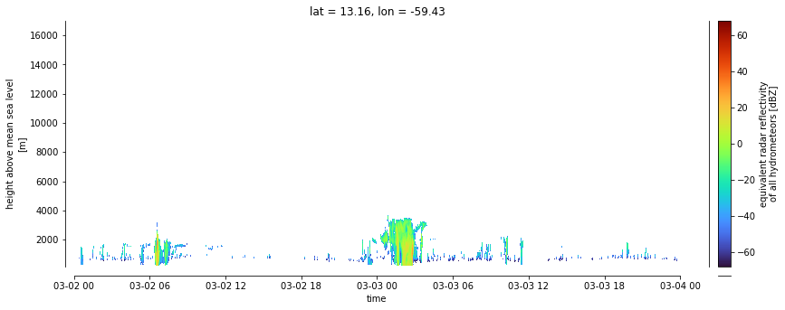

```python
import matplotlib.pyplot as plt # for making plots
import seaborn as sns # for making plots prettier

radar = cat.BCO.radar_MBRS_c1_v1.to_dask()
radar.sel(time=slice("2023-03-02","2023-03-03"),alt=slice(0,17000)).Ze.plot(x="time",cmap="turbo",figsize=(15,5))
sns.despine(offset = 10)
```

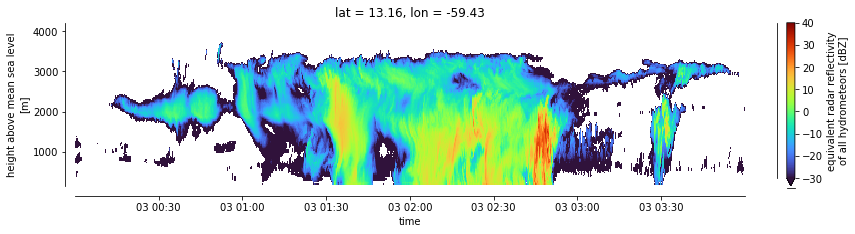

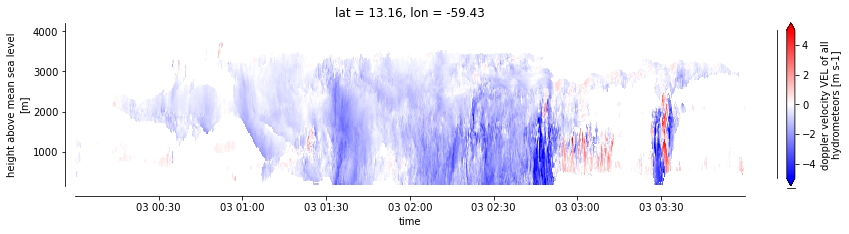

```python
radar = cat.BCO.radar_MBRS_c1_v1.to_dask()
radar.sel(time=slice("2023-03-03T00","2023-03-03T03"),alt=slice(0,4200)).Ze.plot(x="time",cmap="turbo",figsize=(15,3),vmax=40,vmin=-30)
sns.despine(offset = 10)
radar.sel(time=slice("2023-03-03T00","2023-03-03T03"),alt=slice(0,4200)).VEL.plot(x="time",cmap="bwr",figsize=(15,3),vmax=5,vmin=-5)
sns.despine(offset = 10)
```

## Zooming on an interesting velocity feature

In the radar we see an interesting updraft at about 3:30 UTC. Here we zoom in on it.

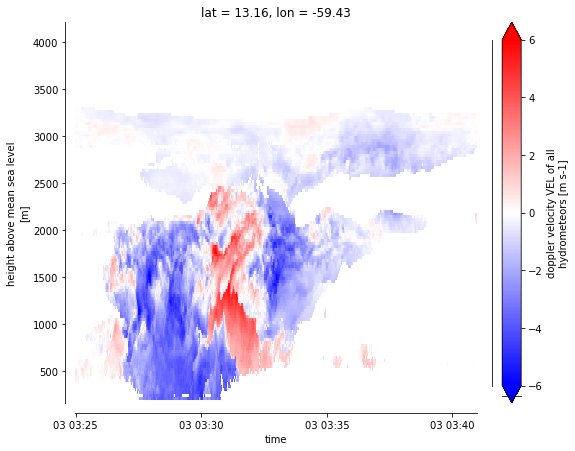

```python
radar.sel(time=slice("2023-03-03T0325","2023-03-03T0340"),alt=slice(0,4200)).VEL.plot(x="time",cmap="bwr",figsize=(9,7),vmax=6,vmin=-6)
sns.despine(offset = 10)
```

## Combining instruments

While the radar makes it look like a long period of rain, most of the reflectivities near the surface would hardly be perceptible as such. Below we plot the near-surface reflectivities as a time-series along with some measurements with the weather station.

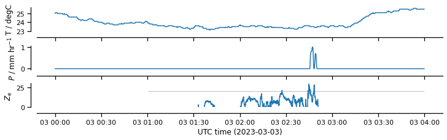

```python
radar = cat.BCO.radar_MBRS_c1_v1.to_dask().sel(time=slice("2023-03-03T01","2023-03-03T03"))
wxt   = cat.BCO.surfacemet_wxt_v1.to_dask().sel(time=slice("2023-03-03T00","2023-03-03T03"))

fig, axs = plt.subplots(3,1, sharex=True, figsize = (10,3),constrained_layout=True)
axs[0].plot(wxt.time,wxt.T)
axs[1].plot(wxt.time,wxt.RI)
axs[2].plot(radar.time,radar.Ze[:,1])
axs[2].set_ylim(0,30.)
axs[2].hlines(20.,xmin=radar.time[0],xmax=radar.time[-1],colors='grey',linestyles='solid',lw=0.5)

axs[0].set_ylabel('T / degC')
axs[1].set_ylabel('$P$ / mm hr$^{-1}$')
axs[2].set_ylabel('$Z_\mathrm{e}$ ')
axs[2].set_xlabel('UTC time (2023-03-03)')

sns.despine(offset = 10)
```

## Synthesizing data with Joint Histograms

We look over the entire record (from Dec 2022 to mid March 2023), nearly 4 million time stamps.

### Making the histograms with seaborn

```python
import numpy as np
import pandas as pd
sns.set_context('notebook')

radar   = cat.BCO.radar_MBRS_c1_v1.to_dask()
ntimes  = len(radar.time)
alts    = radar.alt[500::-5].values  # only look at every fifth height bin to speed up processing

zbins   = np.linspace(-60,30,31)  # specify 30 bins between -60 and 30 dBz reflectivities
vbins   = np.linspace(-8,4,37)    # specify 36 bins between -8 and 4 m/s doppler velocities
zhist   = np.zeros((len(alts),len(zbins)-1))
vhist   = np.zeros((len(alts),len(vbins)-1))

for k,alt in enumerate(alts):
    zhist[k,:], edges = np.histogram(radar.Ze.sel(alt=alt) , bins=zbins, normed=None, weights=None, density=None)
    vhist[k,:], edges = np.histogram(radar.VEL.sel(alt=alt), bins=vbins, normed=None, weights=None, density=None)

zdf = pd.DataFrame(zhist, columns = np.round(zbins[1:]- np.diff(zbins)[0]/2,1), index=np.round(alts/1000.,1) )
vdf = pd.DataFrame(vhist, columns = np.round(vbins[1:]- np.diff(vbins)[0]/2,1), index=np.round(alts/1000.,1) )
```

```python
zdf = pd.DataFrame(zhist, columns = np.round(zbins[1:]- np.diff(zbins)[0]/2,1), index=np.round(alts/1000.,1) )
vdf = pd.DataFrame(vhist, columns = np.round(vbins[1:]- np.diff(vbins)[0]/2,1), index=np.round(alts/1000.,1) )
nmin  = ntimes/3000.
nmax  = ntimes/30.
```

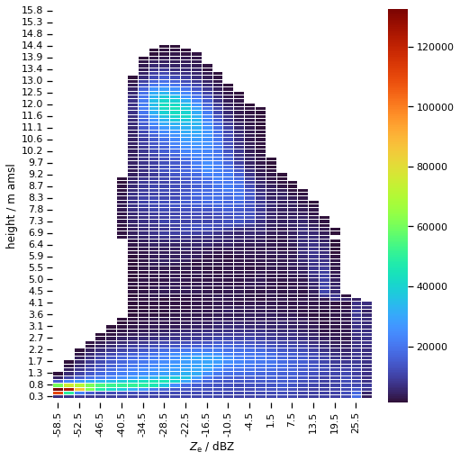

```python
fig, ax = plt.subplots(1,1, figsize = (7,7),constrained_layout=True)
ax    = sns.heatmap(zdf, mask=zdf<nmin,linewidth = 0.5, vmax=nmax,cmap = 'turbo')#, xticklabels=edges, yticklabels=10)
ax.set_xlabel('$Z_\mathrm{e}$ / dBZ',)
ax.set_ylabel('height / m amsl')
```

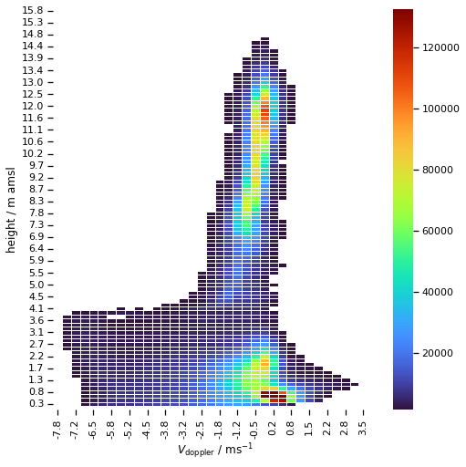

```python
fig, axs = plt.subplots(1,1, figsize = (7,7),constrained_layout=True)
ax    = sns.heatmap(vdf, mask=vdf<nmin,linewidth = 0.5, vmax=nmax,cmap = 'turbo')
ax.set_xlabel('$V_\mathrm{doppler}$ / ms$^{-1}$')
ax.set_ylabel('height / m amsl')
```

## That's it .. but maybe you noticed?

Thanks to the TCO Group for making the data fun and easy.